# W3cubDocs

## Updating billing receipt email and extra receipt information

As an organization owner, you can update the email address used for receipts, and add extra information to the receipt for your paid organization plan, such as your business name, VAT identification number, or address of record. Updated billing information will appear on all receipts immediately.

**Note:** The billing email is used for receipts only and is not required to match the email address of the person whose card is used to pay for the organization.

1. [Log in](https://www.npmjs.com/login) to npm with your user account.

2. In the upper right corner of the page, click your profile picture, then click **Account**.

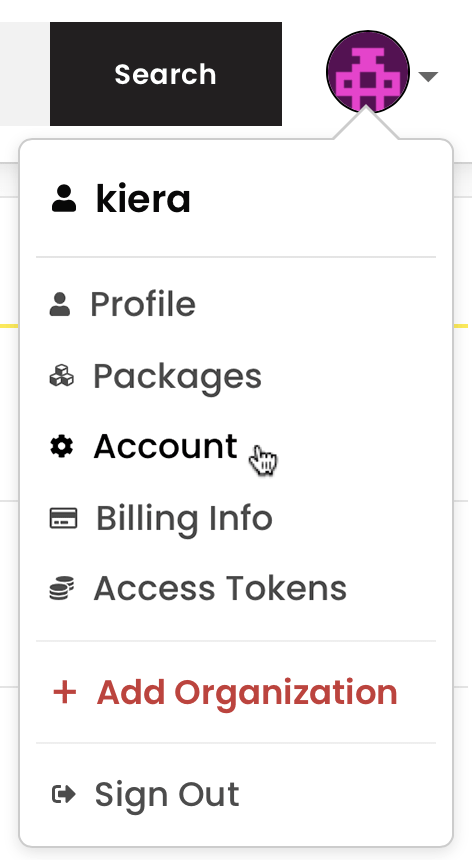

3. In the left sidebar, click the name of the organization whose billing receipt information you want to change.

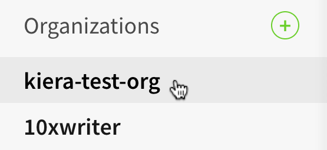

4. On the organization settings page, click **Billing**.
5. On the Billing Information page, under "monthly bill", select **View Billing History**.

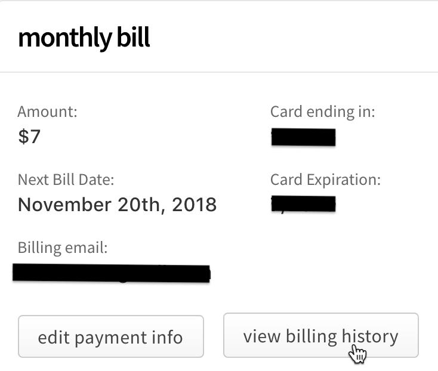

6. At the bottom of the Billing History dialog box, click "Receipt Settings".

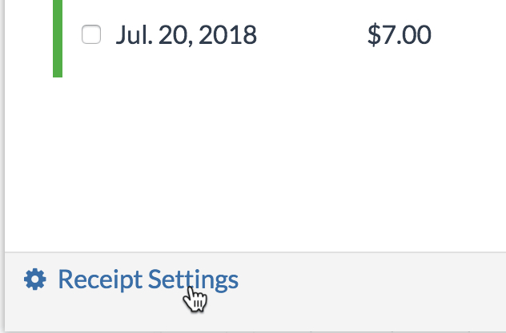

7. To add a business name, VAT number, address of record, or other information to your receipts, in the "Extra Billing Information" text box, type the information.

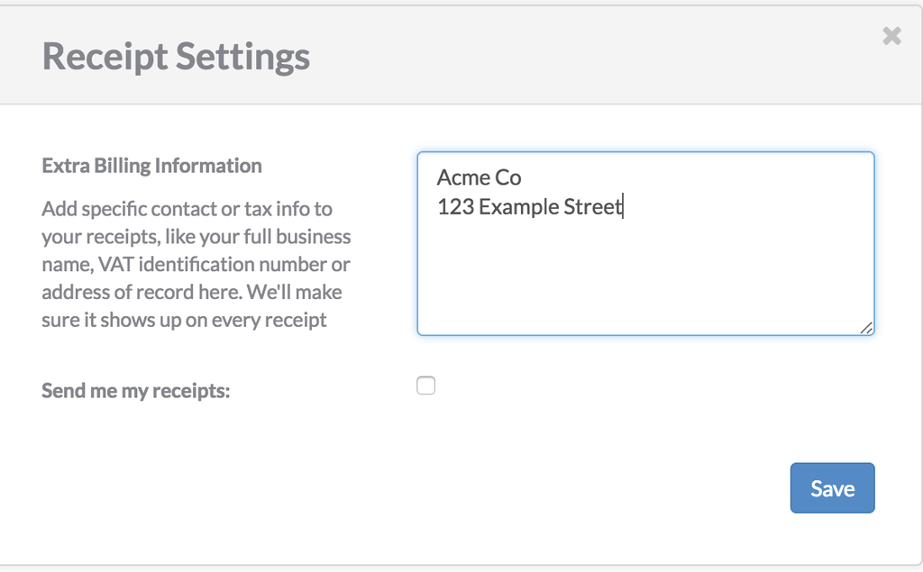

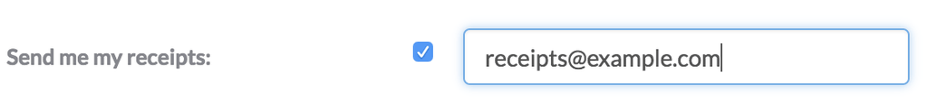

9. Click **Save**.

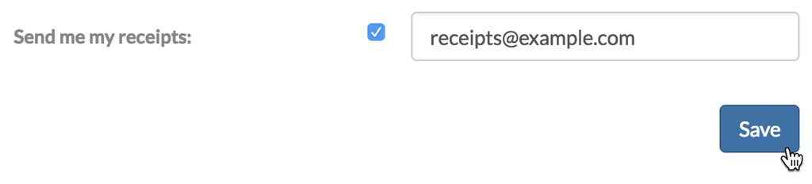